# COTS Fine-Scale SDM: Comprehensive Validation Report

## 2b. Cull Dive Validation (ROC & AUC across Base & Ensemble SDMs)

```r
# --- PART 1: ALL HISTORICAL CULL DIVES (2018-2025) ---
cull_pts_all_sf <- st_as_sf(cull_raw, coords = c("Longitude", "Latitude"), crs = 4326) %>%
  st_transform(crs = crs(prob_year2025))

v_cull_all_pts <- terra::vect(cull_pts_all_sf)

cull_val_all_df <- tibble(
  observed_presence = as.integer(pull(cull_raw, CPUE) >= 0.02),
  CPUE              = pull(cull_raw, CPUE),
  ens_2025     = if(!is.null(prob_ensemble_2025)) as.numeric(terra::extract(prob_ensemble_2025, v_cull_all_pts)[[2]]) else NA_real_,
  ens_agn      = if(!is.null(prob_ensemble_agn))  as.numeric(terra::extract(prob_ensemble_agn, v_cull_all_pts)[[2]]) else NA_real_,
  cull_2025_rg = if(!is.null(prob_2025_rg))       as.numeric(terra::extract(prob_2025_rg, v_cull_all_pts)[[2]]) else NA_real_,
  cull_2025_cl = if(!is.null(prob_year2025))      as.numeric(terra::extract(prob_year2025, v_cull_all_pts)[[2]]) else NA_real_,
  cull_agn_rg  = if(!is.null(prob_agnostic_rg))   as.numeric(terra::extract(prob_agnostic_rg, v_cull_all_pts)[[2]]) else NA_real_,
  cull_agn_cl  = if(!is.null(prob_agnostic_clean)) as.numeric(terra::extract(prob_agnostic_clean, v_cull_all_pts)[[2]]) else NA_real_,
  manta_clean  = if(!is.null(prob_manta_clean))   as.numeric(terra::extract(prob_manta_clean, v_cull_all_pts)[[2]]) else NA_real_,
  manta_rg     = if(!is.null(prob_manta_rg))      as.numeric(terra::extract(prob_manta_rg, v_cull_all_pts)[[2]]) else NA_real_,
  maxent_clean = if(!is.null(prob_maxent))        as.numeric(terra::extract(prob_maxent, v_cull_all_pts)[[2]]) else NA_real_,
  maxent_rg    = if(!is.null(prob_maxent_rg))     as.numeric(terra::extract(prob_maxent_rg, v_cull_all_pts)[[2]]) else NA_real_
) %>% drop_na()

cat("### 2b.1 Performance across ALL Historical Cull Dives (2018–2025: n =", nrow(cull_val_all_df), "dives)\n\n")
```

```
### 2b.1 Performance across ALL Historical Cull Dives (2018–2025: n = 23439 dives)
```

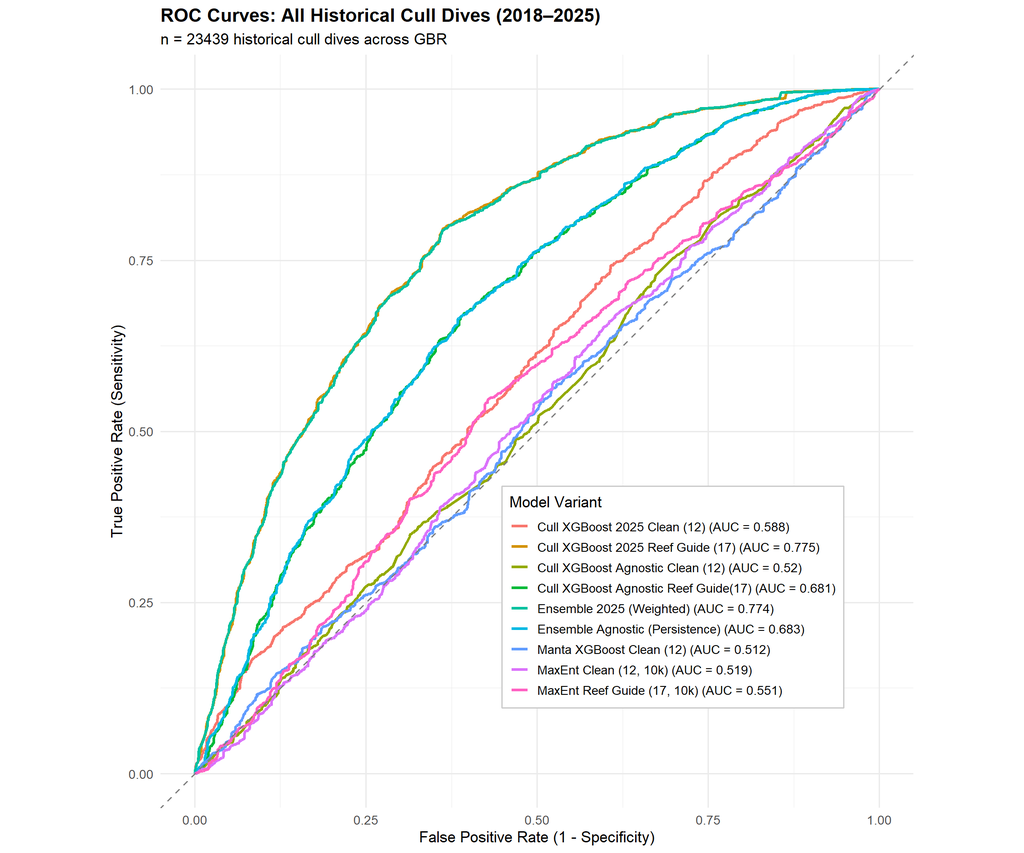

```r
y_true_all <- pull(cull_val_all_df, observed_presence)

roc_models_all <- list(
  "Ensemble 2025 (Weighted)"            = pull(cull_val_all_df, ens_2025),
  "Ensemble Agnostic (Persistence)"     = pull(cull_val_all_df, ens_agn),
  "Cull XGBoost 2025 Reef Guide (17)"   = pull(cull_val_all_df, cull_2025_rg),
  "Cull XGBoost Agnostic Reef Guide(17)"= pull(cull_val_all_df, cull_agn_rg),
  "Cull XGBoost 2025 Clean (12)"        = pull(cull_val_all_df, cull_2025_cl),
  "Cull XGBoost Agnostic Clean (12)"     = pull(cull_val_all_df, cull_agn_cl),
  "MaxEnt Reef Guide (17, 10k)"         = pull(cull_val_all_df, maxent_rg),
  "MaxEnt Clean (12, 10k)"              = pull(cull_val_all_df, maxent_clean),
  "Manta XGBoost Clean (12)"            = pull(cull_val_all_df, manta_clean)
)

roc_df_all_list <- list()
for (m_label in names(roc_models_all)) {
  p_vec <- roc_models_all[[m_label]]
  if (!all(is.na(p_vec))) {
    roc_obj <- pROC::roc(response = y_true_all, predictor = p_vec, quiet = TRUE)
    auc_val <- as.numeric(pROC::auc(roc_obj))
    roc_df_all_list[[m_label]] <- data.frame(
      FPR = 1 - roc_obj$specificities,
      TPR = roc_obj$sensitivities,
      Model = paste0(m_label, " (AUC = ", round(auc_val, 3), ")")
    )
  }
}

p_roc_all <- ggplot(bind_rows(roc_df_all_list), aes(x = FPR, y = TPR, color = Model)) +
  geom_line(linewidth = 1.2) +
  geom_abline(linetype = "dashed", color = "grey50") +
  theme_minimal(base_size = 13) +
  labs(
    title = "ROC Curves: All Historical Cull Dives (2018–2025)",
    subtitle = paste0("n = ", nrow(cull_val_all_df), " historical cull dives across GBR"),
    x = "False Positive Rate (1 - Specificity)",
    y = "True Positive Rate (Sensitivity)",
    color = "Model Variant"
  ) +
  theme(
    plot.title = element_text(face = "bold"),
    legend.position = c(0.68, 0.28),
    legend.background = element_rect(fill = "white", color = "grey80")
  ) +
  coord_equal()

print(p_roc_all)
```

```r
# Detailed metric table across all historical dives
cull_all_metrics_list <- list()
for (m_name in names(roc_models_all)) {
  p_vec <- roc_models_all[[m_name]]
  if (!all(is.na(p_vec))) {
    c_thresh <- median(p_vec, na.rm = TRUE)
    cull_all_metrics_list[[m_name]] <- compute_detailed_metrics(
      truth_vec = y_true_all,
      prob_vec  = p_vec,
      model_name = m_name,
      dataset_name = "All Historical Cull Dives (2018-2025)",
      threshold = c_thresh
    )
  }
}

print(kable(bind_rows(cull_all_metrics_list), caption = "Performance Metrics across ALL Historical Cull Dives (2018–2025, Threshold = Median Probability)"))
```

```
Table: Performance Metrics across ALL Historical Cull Dives (2018–2025, Threshold = Median Probability)

|Model                                |Dataset                               |   AUC| Accuracy| Prec (>0.02)| Rec (>0.02)| F1 (>0.02)| Prec (<0.02)| Rec (<0.02)| F1 (<0.02)|
|:------------------------------------|:-------------------------------------|-----:|--------:|------------:|-----------:|----------:|------------:|-----------:|----------:|
|Ensemble 2025 (Weighted)             |All Historical Cull Dives (2018-2025) | 0.774|    0.687|        0.804|       0.652|      0.720|        0.570|       0.744|      0.645|
|Ensemble Agnostic (Persistence)      |All Historical Cull Dives (2018-2025) | 0.683|    0.624|        0.741|       0.601|      0.664|        0.507|       0.661|      0.574|
|Cull XGBoost 2025 Reef Guide (17)    |All Historical Cull Dives (2018-2025) | 0.775|    0.689|        0.805|       0.654|      0.722|        0.572|       0.745|      0.647|
|Cull XGBoost Agnostic Reef Guide(17) |All Historical Cull Dives (2018-2025) | 0.681|    0.622|        0.740|       0.599|      0.662|        0.505|       0.660|      0.572|
|Cull XGBoost 2025 Clean (12)         |All Historical Cull Dives (2018-2025) | 0.588|    0.547|        0.665|       0.539|      0.595|        0.430|       0.562|      0.487|
|Cull XGBoost Agnostic Clean (12)     |All Historical Cull Dives (2018-2025) | 0.520|    0.507|        0.624|       0.507|      0.560|        0.390|       0.508|      0.441|
|MaxEnt Reef Guide (17, 10k)          |All Historical Cull Dives (2018-2025) | 0.551|    0.556|        0.673|       0.545|      0.602|        0.438|       0.572|      0.496|
|MaxEnt Clean (12, 10k)               |All Historical Cull Dives (2018-2025) | 0.519|    0.515|        0.633|       0.513|      0.566|        0.398|       0.520|      0.451|
|Manta XGBoost Clean (12)             |All Historical Cull Dives (2018-2025) | 0.512|    0.487|        0.604|       0.489|      0.540|        0.369|       0.482|      0.418|
```

```r
cat("\n\n")
```

```r
# --- PART 2: OPERATIONAL 2025 CULL DIVES ---
cull_pts_sub <- cull_raw %>%
  filter(ReefName %in% reef_select_eval, as.Date(SurveyDate) >= as.Date("2025-01-01"))

cull_pts_sf <- st_as_sf(cull_pts_sub, coords = c("Longitude", "Latitude"), crs = 4326) %>%
  st_transform(crs = crs(prob_year2025))

v_cull_pts <- terra::vect(cull_pts_sf)

cull_val_df <- tibble(
  observed_presence = as.integer(pull(cull_pts_sub, CPUE) >= 0.02),
  CPUE              = pull(cull_pts_sub, CPUE),
  cull_clean  = if(!is.null(prob_year2025))    as.numeric(terra::extract(prob_year2025, v_cull_pts)[[2]]) else NA_real_,
  cull_rg     = if(!is.null(prob_2025_rg))     as.numeric(terra::extract(prob_2025_rg, v_cull_pts)[[2]]) else NA_real_,
  cull_agn_rg = if(!is.null(prob_agnostic_rg)) as.numeric(terra::extract(prob_agnostic_rg, v_cull_pts)[[2]]) else NA_real_,
  manta_clean = if(!is.null(prob_manta_clean)) as.numeric(terra::extract(prob_manta_clean, v_cull_pts)[[2]]) else NA_real_,
  manta_rg    = if(!is.null(prob_manta_rg))    as.numeric(terra::extract(prob_manta_rg, v_cull_pts)[[2]]) else NA_real_,
  maxent_clean= if(!is.null(prob_maxent))      as.numeric(terra::extract(prob_maxent, v_cull_pts)[[2]]) else NA_real_,
  maxent_rg   = if(!is.null(prob_maxent_rg))   as.numeric(terra::extract(prob_maxent_rg, v_cull_pts)[[2]]) else NA_real_,
  ensemble    = if(!is.null(prob_ensemble))    as.numeric(terra::extract(prob_ensemble, v_cull_pts)[[2]]) else NA_real_
) %>% drop_na()

cat("### 2b.2 Performance across Operational 2025 Cull Dives (n =", nrow(cull_val_df), "dives)\n\n")
```

```
### 2b.2 Performance across Operational 2025 Cull Dives (n = 1535 dives)
```

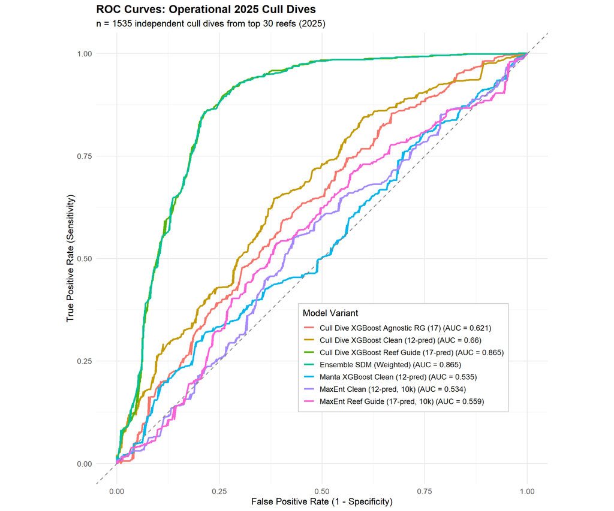

```r
y_true <- pull(cull_val_df, observed_presence)

roc_models <- list(
  "Ensemble SDM (Weighted)"              = pull(cull_val_df, ensemble),
  "Cull Dive XGBoost Reef Guide (17-pred)"= pull(cull_val_df, cull_rg),
  "Cull Dive XGBoost Clean (12-pred)"     = pull(cull_val_df, cull_clean),
  "Cull Dive XGBoost Agnostic RG (17)"   = pull(cull_val_df, cull_agn_rg),
  "MaxEnt Reef Guide (17-pred, 10k)"    = pull(cull_val_df, maxent_rg),
  "MaxEnt Clean (12-pred, 10k)"         = pull(cull_val_df, maxent_clean),
  "Manta XGBoost Clean (12-pred)"       = pull(cull_val_df, manta_clean)
)

roc_df_list <- list()
for (m_label in names(roc_models)) {
  p_vec <- roc_models[[m_label]]
  if (!all(is.na(p_vec))) {
    roc_obj <- pROC::roc(response = y_true, predictor = p_vec, quiet = TRUE)
    auc_val <- as.numeric(pROC::auc(roc_obj))
    roc_df_list[[m_label]] <- data.frame(
      FPR = 1 - roc_obj$specificities,
      TPR = roc_obj$sensitivities,
      Model = paste0(m_label, " (AUC = ", round(auc_val, 3), ")")
    )
  }
}

p_roc <- ggplot(bind_rows(roc_df_list), aes(x = FPR, y = TPR, color = Model)) +
  geom_line(linewidth = 1.2) +
  geom_abline(linetype = "dashed", color = "grey50") +
  theme_minimal(base_size = 13) +
  labs(
    title = "ROC Curves: Operational 2025 Cull Dives",
    subtitle = paste0("n = ", nrow(cull_val_df), " independent cull dives from top 30 reefs (2025)"),
    x = "False Positive Rate (1 - Specificity)",
    y = "True Positive Rate (Sensitivity)",
    color = "Model Variant"
  ) +
  theme(
    plot.title = element_text(face = "bold"),
    legend.position = c(0.68, 0.28),
    legend.background = element_rect(fill = "white", color = "grey80")
  ) +
  coord_equal()

print(p_roc)
```

```r
cull_metrics_list <- list()
for (m_name in names(roc_models)) {
  p_vec <- roc_models[[m_name]]
  if (!all(is.na(p_vec))) {
    c_thresh <- median(p_vec, na.rm = TRUE)
    cull_metrics_list[[m_name]] <- compute_detailed_metrics(
      truth_vec = y_true,
      prob_vec  = p_vec,
      model_name = m_name,
      dataset_name = "2025 Operational Cull Validation",
      threshold = c_thresh
    )
  }
}

print(kable(bind_rows(cull_metrics_list), caption = "Operational 2025 Cull Validation Performance Metrics (Threshold = Median Probability)"))
```

```
Table: Operational 2025 Cull Validation Performance Metrics (Threshold = Median Probability)

|Model                                  |Dataset                          |   AUC| Accuracy| Prec (>0.02)| Rec (>0.02)| F1 (>0.02)| Prec (<0.02)| Rec (<0.02)| F1 (<0.02)|
|:--------------------------------------|:--------------------------------|-----:|--------:|------------:|-----------:|----------:|------------:|-----------:|----------:|
|Ensemble SDM (Weighted)                |2025 Operational Cull Validation | 0.865|    0.728|        0.893|       0.672|      0.767|        0.563|       0.840|      0.674|
|Cull Dive XGBoost Reef Guide (17-pred) |2025 Operational Cull Validation | 0.865|    0.728|        0.893|       0.672|      0.767|        0.563|       0.840|      0.674|
|Cull Dive XGBoost Clean (12-pred)      |2025 Operational Cull Validation | 0.660|    0.603|        0.766|       0.580|      0.660|        0.437|       0.648|      0.522|
|Cull Dive XGBoost Agnostic RG (17)     |2025 Operational Cull Validation | 0.621|    0.577|        0.742|       0.559|      0.638|        0.412|       0.613|      0.493|
|MaxEnt Reef Guide (17-pred, 10k)       |2025 Operational Cull Validation | 0.559|    0.557|        0.722|       0.544|      0.620|        0.392|       0.584|      0.469|
|MaxEnt Clean (12-pred, 10k)            |2025 Operational Cull Validation | 0.534|    0.550|        0.714|       0.541|      0.615|        0.385|       0.570|      0.459|
|Manta XGBoost Clean (12-pred)          |2025 Operational Cull Validation | 0.535|    0.500|        0.665|       0.502|      0.572|        0.334|       0.496|      0.399|
```

```r
cat("\n\n")
```

```r
# --- Optimal thresholds (Youden's J) ---
roc_cull_rg <- pROC::roc(response = y_true, predictor = pull(cull_val_df, cull_rg), quiet = TRUE)
opt_cull_rg <- coords(roc_cull_rg, "best", best.method = "youden", ret = c("threshold", "sensitivity", "specificity"))

cat("Optimal Threshold (Youden's J) for Cull Dive XGBoost Reef Guide Model:", round(opt_cull_rg$threshold, 4),
    "  Sensitivity:", round(opt_cull_rg$sensitivity, 3),
    "  Specificity:", round(opt_cull_rg$specificity, 3), "\n\n")
```

```
Optimal Threshold (Youden's J) for Cull Dive XGBoost Reef Guide Model: 0.5718   Sensitivity: 0.858   Specificity: 0.786
```

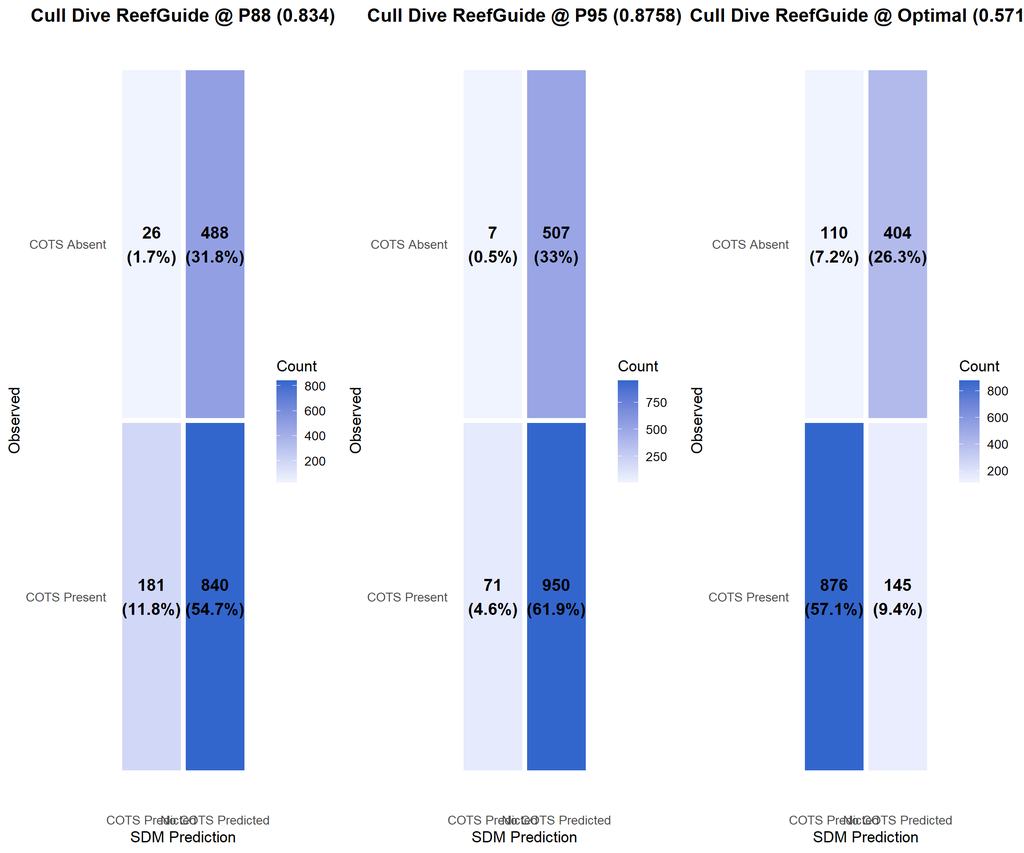

```r
# --- Confusion Matrices at P88 and P95 thresholds ---
thresh_rg_p88 <- quantile(cull_val_df$cull_rg, 0.88, na.rm = TRUE)
thresh_rg_p95 <- quantile(cull_val_df$cull_rg, 0.95, na.rm = TRUE)

plot_cull_cm <- function(prob_vec, obs_vec, threshold, title) {
  cm_df <- data.frame(
    Predicted = factor(ifelse(prob_vec >= threshold, "COTS Predicted", "No COTS Predicted"),
                       levels = c("COTS Predicted", "No COTS Predicted")),
    Observed  = factor(ifelse(obs_vec, "COTS Present", "COTS Absent"),
                       levels = c("COTS Present", "COTS Absent"))
  )
  cm_counts <- cm_df %>%
    count(Predicted, Observed) %>%
    group_by() %>%
    mutate(pct = n / sum(n) * 100)

  ggplot(cm_counts, aes(x = Predicted, y = Observed, fill = n)) +
    geom_tile(color = "white", linewidth = 2) +
    geom_text(aes(label = paste0(n, "\n(", round(pct, 1), "%)")), size = 5, fontface = "bold") +
    scale_fill_gradient(low = "#f0f4ff", high = "#3366cc") +
    theme_minimal(base_size = 13) +
    labs(title = title, x = "SDM Prediction", y = "Observed", fill = "Count") +
    theme(plot.title = element_text(face = "bold", hjust = 0.5), panel.grid = element_blank())
}

p_cm1 <- plot_cull_cm(cull_val_df$cull_rg, cull_val_df$observed_presence == 1,
                       thresh_rg_p88, paste0("Cull Dive ReefGuide @ P88 (", round(thresh_rg_p88, 4), ")"))
p_cm2 <- plot_cull_cm(cull_val_df$cull_rg, cull_val_df$observed_presence == 1,
                       thresh_rg_p95, paste0("Cull Dive ReefGuide @ P95 (", round(thresh_rg_p95, 4), ")"))
p_cm3 <- plot_cull_cm(cull_val_df$cull_rg, cull_val_df$observed_presence == 1,
                       opt_cull_rg$threshold, paste0("Cull Dive ReefGuide @ Optimal (", round(opt_cull_rg$threshold, 4), ")"))

gridExtra::grid.arrange(p_cm1, p_cm2, p_cm3, ncol = 3)
```

## 3. Step B: Tow-Path Simulation and Evaluation

Simulating whether a specific tow path would have been suggested by the 2025 SDM model. We evaluate hit-rates strictly against tows conducted from Jan 1 2025 onwards, however, we use all historic tow tracks to delineate the operational boundaries.

```r
# 2. Define Regions (100m Buffered Tows & 200m Grids)
tow_regions_list <- list()
grid_regions_list <- list()

for (r_name in unique(manta_eval_all$ReefName)) {
  m_sub <- manta_eval_all %>% filter(ReefName == r_name)
  if (nrow(m_sub) == 0) next

  bb <- st_bbox(m_sub)
  gr_500 <- st_make_grid(bb, cellsize = 500, square = TRUE) %>% st_as_sf()

  # Tow Regions (100m buffer, unioned, then intersected with 500m grid)
  tr <- st_buffer(m_sub, dist = 100) %>%
    st_union() %>%
    st_intersection(gr_500) %>%
    st_cast("POLYGON") %>%
    st_as_sf() %>%
    mutate(ReefName = r_name, RegionType = "Tow_100m_Seg500m", RegionID = paste0(r_name, "_T_", row_number())) %>%
    rename(geometry = x)
  tow_regions_list[[r_name]] <- tr

  # Grid Regions (200m x 200m)
  gr <- st_make_grid(bb, cellsize = 200, square = TRUE) %>%
    st_as_sf() %>%
    mutate(ReefName = r_name, RegionType = "Grid_200m", RegionID = paste0(r_name, "_G_", row_number())) %>%
    rename(geometry = x)

  # Keep only grid cells that intersect with manta tows to avoid evaluating empty ocean
  gr <- gr[lengths(st_intersects(gr, m_sub)) > 0, ]

  grid_regions_list[[r_name]] <- gr
}

tow_regions <- bind_rows(tow_regions_list)
grid_regions <- bind_rows(grid_regions_list)
all_regions <- bind_rows(tow_regions, grid_regions)

# 3. Extract SDM Stats for Regions
extract_poly_stats <- function(r, polys) {
  v <- terra::vect(polys)
  ex <- terra::extract(r, v)
  val_col <- setdiff(names(ex), "ID")[1]

  ex %>%
    rename(poly_id = ID, value = !!val_col) %>%
    group_by(poly_id) %>%
    summarise(
      reg_p88    = as.numeric(quantile(value, probs = 0.88, na.rm = TRUE, names = FALSE)),
      reg_p95    = as.numeric(quantile(value, probs = 0.95, na.rm = TRUE, names = FALSE)),
      .groups    = "drop"
    )
}

all_regions$poly_id <- seq_len(nrow(all_regions))
region_stats <- extract_poly_stats(prob_year2025, all_regions)

all_regions <- all_regions %>% left_join(region_stats, by = "poly_id")
tow_regions <- all_regions %>% filter(RegionType == "Tow_100m_Seg500m")
grid_regions <- all_regions %>% filter(RegionType == "Grid_200m")

# 4. Map Tows to Regions and Apply Thresholds
# using st_join(largest = TRUE) ensures a tow is assigned to only one region
m_tow <- st_join(manta_eval_all, tow_regions %>% select(RegionID_Tow = RegionID, reg_p88_Tow = reg_p88, reg_p95_Tow = reg_p95), largest = TRUE)
m_grid <- st_join(manta_eval_all, grid_regions %>% select(RegionID_Grid = RegionID, reg_p88_Grid = reg_p88, reg_p95_Grid = reg_p95), largest = TRUE)

manta_eval <- manta_eval_all %>%
  mutate(
    reg_p88_Tow = m_tow$reg_p88_Tow,
    reg_p95_Tow = m_tow$reg_p95_Tow,
    reg_p88_Grid = m_grid$reg_p88_Grid,
    reg_p95_Grid = m_grid$reg_p95_Grid
  ) %>%
  mutate(
    sug_Tow_P88 = !is.na(reg_p88_Tow) & reg_p88_Tow >= thresh_2025_p88,
    sug_Tow_P95 = !is.na(reg_p95_Tow) & reg_p95_Tow >= thresh_2025_p95,
    sug_Grid_P88 = !is.na(reg_p88_Grid) & reg_p88_Grid >= thresh_2025_p88,
    sug_Grid_P95 = !is.na(reg_p95_Grid) & reg_p95_Grid >= thresh_2025_p95
  )

# Function to compute hit rates by reef for a specific scenario
calc_hit_rates_reef <- function(df, scenario_col, scenario_name) {
  overall <- df %>%
    summarise(
      ReefName = "Overall",
      Scenario = scenario_name,
      Total_Tows = n(),
      Tows_Suggested = sum(!!sym(scenario_col), na.rm=TRUE),
      Hit_Rate = sum(!!sym(scenario_col) & presence_any, na.rm=TRUE) / Tows_Suggested,
      Tows_Avoided = sum(! (!!sym(scenario_col)), na.rm=TRUE),
      Miss_Rate = sum(! (!!sym(scenario_col)) & presence_any, na.rm=TRUE) / Tows_Avoided
    )
  by_reef <- df %>%
    group_by(ReefName) %>%
    summarise(
      Scenario = scenario_name,
      Total_Tows = n(),
      Tows_Suggested = sum(!!sym(scenario_col), na.rm=TRUE),
      Hit_Rate = sum(!!sym(scenario_col) & presence_any, na.rm=TRUE) / Tows_Suggested,
      Tows_Avoided = sum(! (!!sym(scenario_col)), na.rm=TRUE),
      Miss_Rate = sum(! (!!sym(scenario_col)) & presence_any, na.rm=TRUE) / Tows_Avoided
    )
  bind_rows(by_reef, overall)
}

manta_eval_2025 <- manta_eval %>% filter(as.Date(SurveyTime) >= as.Date("2025-01-01"))

hit_table <- bind_rows(
  calc_hit_rates_reef(manta_eval_2025 %>% filter(ReefName %in% reef_select), "sug_Tow_P88", "Seg Tow 100m + P88"),
  calc_hit_rates_reef(manta_eval_2025 %>% filter(ReefName %in% reef_select), "sug_Tow_P95", "Seg Tow 100m + P95")
) %>% arrange(ReefName, desc(Scenario))

kable(hit_table, digits = 3, caption = "Manta Tow Simulation: Operational Zonal Validation (Selected 10 Reefs)")
```

Manta Tow Simulation: Operational Zonal Validation (Selected 10 Reefs)

| ReefName | Scenario | Total_Tows | Tows_Suggested | Hit_Rate | Tows_Avoided | Miss_Rate | geometry |
| --- | --- | --- | --- | --- | --- | --- | --- |
| (Big) Broadhurst Reef (No 1) (18-100a) | Seg Tow 100m + P95 | 637 | 332 | 0.099 | 305 | 0.128 | MULTILINESTRING ((573577.7 … |
| (Big) Broadhurst Reef (No 1) (18-100a) | Seg Tow 100m + P88 | 637 | 185 | 0.076 | 452 | 0.128 | MULTILINESTRING ((573577.7 … |
| Batt Reef (16-029) | Seg Tow 100m + P95 | 382 | 344 | 0.308 | 38 | 0.026 | MULTILINESTRING ((377707.6 … |
| Batt Reef (16-029) | Seg Tow 100m + P88 | 382 | 317 | 0.312 | 65 | 0.123 | MULTILINESTRING ((377707.6 … |
| Davies Reef (18-096) | Seg Tow 100m + P95 | 177 | 100 | 0.200 | 77 | 0.260 | MULTILINESTRING ((566203.3 … |
| Davies Reef (18-096) | Seg Tow 100m + P88 | 177 | 60 | 0.117 | 117 | 0.282 | MULTILINESTRING ((566203.3 … |
| Heron Reef (23-052a) | Seg Tow 100m + P95 | 217 | 163 | 0.147 | 54 | 0.093 | MULTILINESTRING ((1003623 7… |
| Heron Reef (23-052a) | Seg Tow 100m + P88 | 217 | 154 | 0.149 | 63 | 0.095 | MULTILINESTRING ((1003623 7… |
| Overall | Seg Tow 100m + P95 | 1413 | 939 | 0.195 | 474 | 0.137 | MULTILINESTRING ((377707.6 … |
| Overall | Seg Tow 100m + P88 | 1413 | 716 | 0.200 | 697 | 0.151 | MULTILINESTRING ((377707.6 … |

## 4. Step C: Cull Dive Financial Savings

Evaluating cull dives strictly from Jan 1 2025 onwards using the 2025 P88 and P95 thresholds on Segmented Tow Regions. We quantify avoided diving hours for dives that resulted in 0.00 CPUE (Ghost Culls) and <0.02 CPUE (Non-Problematic), and calculate financial savings ($950/hr).

```r
# --- Step 1: Build cull geometry using polygons where available, points otherwise ---
# Join cull data to polygon geometries by CullSiteName
cull_eval_raw <- cull_raw %>% filter(ReefName %in% reef_select_eval)
cull_eval_raw$row_id <- seq_len(nrow(cull_eval_raw))

# Match cull site names to polygon geometries
poly_lookup <- cull_site_polys %>% select(CullSiteName)

matched_idx <- cull_eval_raw$CullSiteName %in% poly_lookup$CullSiteName
cat("Cull site polygon match rate:", round(mean(matched_idx) * 100, 1), "%\n")
```

```
Cull site polygon match rate: 100 %
```

```r
cat("  Matched:", sum(matched_idx), "  Unmatched:", sum(!matched_idx), "\n")
```

```
  Matched: 9426   Unmatched: 0
```

```r
# For matched: use polygon + 50m buffer
if (sum(matched_idx) > 0) {
  # Look up the polygon for each matched cull record
  match_positions <- match(cull_eval_raw$CullSiteName[matched_idx], poly_lookup$CullSiteName)
  matched_geoms <- st_buffer(st_geometry(poly_lookup)[match_positions], dist = 50)
  cull_matched_sf2 <- st_sf(cull_eval_raw[matched_idx, ], geometry = matched_geoms)
  cull_matched_sf2$match_type <- "Polygon"
} else {
  cull_matched_sf2 <- NULL
}

# For unmatched: use point + 100m buffer
if (sum(!matched_idx) > 0) {
  cull_unmatched_pts <- st_as_sf(cull_eval_raw[!matched_idx, ],
    coords = c("Longitude", "Latitude"), crs = 4326) %>%
    st_transform(crs = crs(prob_year2025))
  cull_unmatched_buf <- st_buffer(cull_unmatched_pts, dist = 100)
  cull_unmatched_buf$match_type <- "Point (100m buffer)"
} else {
  cull_unmatched_buf <- NULL
}

# Combine into single sf
cull_sf_combined <- bind_rows(cull_matched_sf2, cull_unmatched_buf) %>%
  arrange(row_id)

cat("Combined cull geometries:", nrow(cull_sf_combined), "rows\n")
```

```
Combined cull geometries: 9426 rows
```

```r
# --- Step 2: Spatial join to tow/grid regions ---
c_tow  <- st_join(cull_sf_combined, tow_regions  %>% select(RegionID_Tow  = RegionID, reg_p88_Tow  = reg_p88, reg_p95_Tow  = reg_p95),  largest = TRUE)
c_grid <- st_join(cull_sf_combined, grid_regions %>% select(RegionID_Grid = RegionID, reg_p88_Grid = reg_p88, reg_p95_Grid = reg_p95), largest = TRUE)

# --- Step 3: Sector join (using centroids for sector assignment) ---
sectors_sf <- st_read("data/SectorShapefile/ltms.shp", quiet = TRUE) %>%
  st_transform(crs = crs(prob_year2025))
cull_centroids <- st_centroid(cull_sf_combined)
c_sector <- st_join(cull_centroids, sectors_sf %>% select(SECTOR_NAM), join = st_nearest_feature)

# --- Step 4: For unmatched tow-region NAs, extract MEAN raster value across the cull polygon/buffer ---
na_tow_idx <- is.na(c_tow$reg_p88_Tow)
cat("Tow region NA count:", sum(na_tow_idx), "of", nrow(c_tow), "\n")
```

```
Tow region NA count: 12 of 9426
```

```r
# Extract mean raster value for each cull site polygon/buffer that didn't match a tow region
if (sum(na_tow_idx) > 0) {
  na_polys <- cull_sf_combined[na_tow_idx, ]
  na_extract <- terra::extract(prob_year2025, terra::vect(na_polys), fun = "mean", na.rm = TRUE)
  val_col <- setdiff(names(na_extract), "ID")[1]
  inferred_vals <- na_extract[[val_col]]
} else {
  inferred_vals <- numeric(0)
}

# --- Step 5: Build cull_eval with combined logic ---
cull_eval <- cull_sf_combined %>%
  st_drop_geometry() %>%
  mutate(
    reg_p88_Tow  = c_tow$reg_p88_Tow,
    reg_p95_Tow  = c_tow$reg_p95_Tow,
    reg_p88_Grid = c_grid$reg_p88_Grid,
    reg_p95_Grid = c_grid$reg_p95_Grid,
    SECTOR_NAM   = c_sector$SECTOR_NAM
  )

# For NAs: fill in with inferred raster mean value
cull_eval$inferred_mean <- NA_real_
cull_eval$inferred_mean[na_tow_idx] <- inferred_vals

cull_eval <- cull_eval %>%
  mutate(
    # Region-matched classification
    avoid_Tow_P88 = case_when(
      !is.na(reg_p88_Tow) ~ reg_p88_Tow < thresh_2025_p88,
      TRUE                 ~ inferred_mean < thresh_2025_p88
    ),
    avoid_Tow_P95 = case_when(
      !is.na(reg_p95_Tow) ~ reg_p95_Tow < thresh_2025_p95,
      TRUE                 ~ inferred_mean < thresh_2025_p95
    ),
    avoid_Grid_P88 = case_when(
      !is.na(reg_p88_Grid) ~ reg_p88_Grid < thresh_2025_p88,
      TRUE                  ~ inferred_mean < thresh_2025_p88
    ),
    avoid_Grid_P95 = case_when(
      !is.na(reg_p95_Grid) ~ reg_p95_Grid < thresh_2025_p95,
      TRUE                  ~ inferred_mean < thresh_2025_p95
    ),
    # Transparency flag
    classification_type = case_when(
      !is.na(reg_p88_Tow) ~ "Region Matched",
      !is.na(inferred_mean) ~ "Inferred",
      TRUE ~ "Unknown"
    )
  )

cat("\nClassification type breakdown:\n")
```

```
Classification type breakdown:
```

```r
print(table(cull_eval$classification_type))
```

```
      Inferred Region Matched
            12           9414
```

```r
diver_hour_cost <- 950

calc_savings_reef <- function(df, avoid_col, scenario_name) {
  overall <- df %>%
    summarise(
      ReefName = "Overall",
      Scenario = scenario_name,
      Ghost_Avoided = sum(is_ghost & !!sym(avoid_col)),
      Ghost_Savings = sum(Bottomtime[is_ghost & !!sym(avoid_col)]) / 60 * diver_hour_cost,
      NonProb_Avoided = sum(is_non_problematic & !!sym(avoid_col)),
      NonProb_Savings = sum(Bottomtime[is_non_problematic & !!sym(avoid_col)]) / 60 * diver_hour_cost,
      Total_Savings = Ghost_Savings + NonProb_Savings,
      Prob_Missed = sum(!is_non_problematic & !!sym(avoid_col)),
      COTS_Missed = sum(Total[!is_non_problematic & !!sym(avoid_col)]),
      Pct_COTS_Missed = ifelse(sum(Total) > 0, COTS_Missed / sum(Total) * 100, 0),
      Hours_Missed = sum(Bottomtime[!is_non_problematic & !!sym(avoid_col)]) / 60
    ) %>%
    mutate(
      CPUE_Missed = ifelse(Hours_Missed > 0, COTS_Missed / (Hours_Missed * 60), 0)
    )
  by_reef <- df %>%
    group_by(ReefName) %>%
    summarise(
      Scenario = scenario_name,
      Ghost_Avoided = sum(is_ghost & !!sym(avoid_col)),
      Ghost_Savings = sum(Bottomtime[is_ghost & !!sym(avoid_col)]) / 60 * diver_hour_cost,
      NonProb_Avoided = sum(is_non_problematic & !!sym(avoid_col)),
      NonProb_Savings = sum(Bottomtime[is_non_problematic & !!sym(avoid_col)]) / 60 * diver_hour_cost,
      Total_Savings = Ghost_Savings + NonProb_Savings,
      Prob_Missed = sum(!is_non_problematic & !!sym(avoid_col)),
      COTS_Missed = sum(Total[!is_non_problematic & !!sym(avoid_col)]),
      Pct_COTS_Missed = ifelse(sum(Total) > 0, COTS_Missed / sum(Total) * 100, 0),
      Hours_Missed = sum(Bottomtime[!is_non_problematic & !!sym(avoid_col)]) / 60
    ) %>%
    mutate(
      CPUE_Missed = ifelse(Hours_Missed > 0, COTS_Missed / (Hours_Missed * 60), 0)
    )
  bind_rows(by_reef, overall)
}

cull_eval_2025 <- cull_eval %>%
  filter(as.Date(SurveyDate) >= as.Date("2025-01-01")) %>%
  mutate(
    SECTOR_NAM = as.character(SECTOR_NAM),
    ManagementZone = case_when(
      SECTOR_NAM %in% c("Cape Grenville", "Princess Charlotte Bay") ~ "Far Northern",
      SECTOR_NAM %in% c("Cooktown / Lizard Island", "Cairns", "Innisfail") ~ "Northern",
      SECTOR_NAM %in% c("Townsville", "Cape Upstart", "Whitsunday") ~ "Central",
      SECTOR_NAM %in% c("Pompey", "Swain", "Capricorn Bunker") ~ "Southern",
      TRUE ~ "Unknown"
    )
  )

# Only show reef-level summary for the 10 selected reefs to avoid massive tables
savings_table <- bind_rows(
  calc_savings_reef(cull_eval_2025 %>% filter(ReefName %in% reef_select), "avoid_Tow_P88", "Seg Tow 100m + P88"),
  calc_savings_reef(cull_eval_2025 %>% filter(ReefName %in% reef_select), "avoid_Tow_P95", "Seg Tow 100m + P95")
) %>% arrange(ReefName, desc(Scenario))

kable(savings_table, digits = 2, format.args = list(big.mark = ","), caption = "Financial Savings and Risk Summary (Selected 10 Reefs)")
```

Financial Savings and Risk Summary (Selected 10 Reefs)

| ReefName | Scenario | Ghost_Avoided | Ghost_Savings | NonProb_Avoided | NonProb_Savings | Total_Savings | Prob_Missed | COTS_Missed | Pct_COTS_Missed | Hours_Missed | CPUE_Missed |
| --- | --- | --- | --- | --- | --- | --- | --- | --- | --- | --- | --- |
| (Big) Broadhurst Reef (No 1) (18-100a) | Seg Tow 100m + P95 | 14 | 55,654.17 | 31 | 139,254.17 | 194,908.33 | 14 | 185 | 16.59 | 83.33 | 0.04 |
| (Big) Broadhurst Reef (No 1) (18-100a) | Seg Tow 100m + P88 | 26 | 97,897.50 | 51 | 211,960.83 | 309,858.33 | 24 | 430 | 38.57 | 133.33 | 0.05 |
| Batt Reef (16-029) | Seg Tow 100m + P95 | 0 | 0.00 | 0 | 0.00 | 0.00 | 0 | 0 | 0.00 | 0.00 | 0.00 |
| Batt Reef (16-029) | Seg Tow 100m + P88 | 1 | 2,533.33 | 1 | 2,533.33 | 5,066.67 | 14 | 277 | 6.29 | 77.50 | 0.06 |
| Davies Reef (18-096) | Seg Tow 100m + P95 | 1 | 3,483.33 | 12 | 39,963.33 | 43,446.67 | 13 | 94 | 43.52 | 49.87 | 0.03 |
| Davies Reef (18-096) | Seg Tow 100m + P88 | 1 | 3,483.33 | 16 | 52,946.67 | 56,430.00 | 17 | 113 | 52.31 | 62.93 | 0.03 |
| Heron Reef (23-052a) | Seg Tow 100m + P95 | 1 | 5,510.00 | 6 | 29,925.00 | 35,435.00 | 0 | 0 | 0.00 | 0.00 | 0.00 |
| Heron Reef (23-052a) | Seg Tow 100m + P88 | 1 | 5,510.00 | 7 | 34,295.00 | 39,805.00 | 0 | 0 | 0.00 | 0.00 | 0.00 |
| Overall | Seg Tow 100m + P95 | 16 | 64,647.50 | 49 | 209,142.50 | 273,790.00 | 27 | 279 | 4.59 | 133.20 | 0.03 |
| Overall | Seg Tow 100m + P88 | 29 | 109,424.17 | 75 | 301,735.83 | 411,160.00 | 55 | 820 | 13.50 | 273.77 | 0.05 |

```r
# Management Zone & Sector Summary (All 128 Reefs)
calc_savings_zone <- function(df, avoid_col, scenario_name) {
  df %>%
    group_by(ManagementZone, SECTOR_NAM) %>%
    summarise(
      Scenario = scenario_name,
      Ghost_Savings = sum(Bottomtime[is_ghost & !!sym(avoid_col)]) / 60 * diver_hour_cost,
      NonProb_Savings = sum(Bottomtime[is_non_problematic & !!sym(avoid_col)]) / 60 * diver_hour_cost,
      Total_Savings = Ghost_Savings + NonProb_Savings,
      COTS_Missed = sum(Total[!is_non_problematic & !!sym(avoid_col)]),
      Pct_COTS_Missed = ifelse(sum(Total) > 0, COTS_Missed / sum(Total) * 100, 0),
      Hours_Missed = sum(Bottomtime[!is_non_problematic & !!sym(avoid_col)]) / 60,
      .groups = "drop"
    )
}

savings_zone_table <- bind_rows(
  calc_savings_zone(cull_eval_2025, "avoid_Tow_P88", "Seg Tow 100m + P88"),
  calc_savings_zone(cull_eval_2025, "avoid_Tow_P95", "Seg Tow 100m + P95")
) %>%
  arrange(factor(ManagementZone, levels = c("Far Northern", "Northern", "Central", "Southern", "Unknown")), SECTOR_NAM, desc(Scenario))

kable(savings_zone_table, digits = 2, format.args = list(big.mark = ","), caption = "Financial Savings and Risk Summary by Management Zone & Sector (Top 30 Reefs, 2025)")
```

Financial Savings and Risk Summary by Management Zone & Sector (Top 30 Reefs, 2025)

| ManagementZone | SECTOR_NAM | Scenario | Ghost_Savings | NonProb_Savings | Total_Savings | COTS_Missed | Pct_COTS_Missed | Hours_Missed |
| --- | --- | --- | --- | --- | --- | --- | --- | --- |
| Far Northern | Cape Grenville | Seg Tow 100m + P95 | 9,468.33 | 42,085.00 | 51,553.33 | 428 | 48.20 | 94.42 |
| Far Northern | Cape Grenville | Seg Tow 100m + P88 | 9,468.33 | 62,747.50 | 72,215.83 | 610 | 68.69 | 152.88 |
| Northern | Cairns | Seg Tow 100m + P95 | 26,916.67 | 32,458.33 | 59,375.00 | 0 | 0.00 | 0.00 |
| Northern | Cairns | Seg Tow 100m + P88 | 29,450.00 | 70,125.83 | 99,575.83 | 588 | 10.55 | 184.33 |
| Northern | Cooktown / Lizard Island | Seg Tow 100m + P95 | 490.83 | 23,607.50 | 24,098.33 | 663 | 7.13 | 133.93 |
| Northern | Cooktown / Lizard Island | Seg Tow 100m + P88 | 490.83 | 53,849.17 | 54,340.00 | 1,191 | 12.82 | 266.75 |
| Northern | Innisfail | Seg Tow 100m + P95 | 0.00 | 0.00 | 0.00 | 0 | 0.00 | 0.00 |
| Northern | Innisfail | Seg Tow 100m + P88 | 6,016.67 | 37,366.67 | 43,383.33 | 25 | 2.21 | 13.33 |
| Central | Cape Upstart | Seg Tow 100m + P95 | 34,643.33 | 63,903.33 | 98,546.67 | 22 | 13.25 | 10.17 |
| Central | Cape Upstart | Seg Tow 100m + P88 | 66,373.33 | 105,386.67 | 171,760.00 | 68 | 40.96 | 25.17 |
| Central | Townsville | Seg Tow 100m + P95 | 65,945.83 | 353,669.17 | 419,615.00 | 647 | 10.01 | 290.83 |
| Central | Townsville | Seg Tow 100m + P88 | 116,881.67 | 494,601.67 | 611,483.33 | 1,230 | 19.04 | 419.53 |
| Southern | Capricorn Bunker | Seg Tow 100m + P95 | 28,785.00 | 147,535.00 | 176,320.00 | 664 | 14.66 | 129.88 |
| Southern | Capricorn Bunker | Seg Tow 100m + P88 | 31,207.50 | 174,356.67 | 205,564.17 | 934 | 20.62 | 188.78 |
| Southern | Swain | Seg Tow 100m + P95 | 46,122.50 | 107,255.00 | 153,377.50 | 487 | 20.51 | 94.88 |
| Southern | Swain | Seg Tow 100m + P88 | 61,180.00 | 145,967.50 | 207,147.50 | 696 | 29.31 | 159.20 |

```r
# --- Consolidated Scenario Summary ---
scenario_summary <- function(manta_df, cull_df, tow_col, avoid_col, label) {
  # Manta tow summary
  m <- manta_df %>%
    summarise(
      Total_Tows = n(),
      Tows_Suggested = sum(!!sym(tow_col), na.rm=TRUE),
      Tows_Avoided = Total_Tows - Tows_Suggested,
      Hit_Rate = sum(!!sym(tow_col) & presence_any, na.rm=TRUE) / max(Tows_Suggested, 1),
      Miss_Rate = sum(!(!!sym(tow_col)) & presence_any, na.rm=TRUE) / max(Tows_Avoided, 1)
    )
  # Cull dive summary
  c <- cull_df %>%
    summarise(
      Total_Dives = n(),
      Dives_Avoided = sum(!!sym(avoid_col), na.rm=TRUE),
      Ghost_Savings = sum(Bottomtime[is_ghost & !!sym(avoid_col)]) / 60 * diver_hour_cost,
      NonProb_Savings = sum(Bottomtime[is_non_problematic & !!sym(avoid_col)]) / 60 * diver_hour_cost,
      Total_Savings = Ghost_Savings + NonProb_Savings,
      COTS_Missed = sum(Total[!is_non_problematic & !!sym(avoid_col)]),
      Pct_COTS_Missed = ifelse(sum(Total) > 0, COTS_Missed / sum(Total) * 100, 0)
    )
  tibble(
    Scenario = label,
    Total_Tows = m$Total_Tows, Tows_Suggested = m$Tows_Suggested, Tows_Avoided = m$Tows_Avoided,
    Tow_Hit_Rate = m$Hit_Rate, Tow_Miss_Rate = m$Miss_Rate,
    Total_Dives = c$Total_Dives, Dives_Avoided = c$Dives_Avoided,
    Total_Savings = c$Total_Savings, COTS_Missed = c$COTS_Missed, Pct_COTS_Missed = c$Pct_COTS_Missed
  )
}

consolidated <- bind_rows(
  scenario_summary(manta_eval_2025, cull_eval_2025, "sug_Tow_P88", "avoid_Tow_P88", "P88 (Aggressive)"),
  scenario_summary(manta_eval_2025, cull_eval_2025, "sug_Tow_P95", "avoid_Tow_P95", "P95 (Conservative)")
)

kable(consolidated, digits = 2, format.args = list(big.mark = ","),
      caption = "Consolidated Scenario Comparison: Manta Tow + Cull Dive (All Top 30 Reefs, 2025)")
```

Consolidated Scenario Comparison: Manta Tow + Cull Dive (All Top 30 Reefs, 2025)

| Scenario | Total_Tows | Tows_Suggested | Tows_Avoided | Tow_Hit_Rate | Tow_Miss_Rate | Total_Dives | Dives_Avoided | Total_Savings | COTS_Missed | Pct_COTS_Missed |
| --- | --- | --- | --- | --- | --- | --- | --- | --- | --- | --- |
| P88 (Aggressive) | 7,757 | 4,090 | 3,667 | 0.15 | 0.16 | 1,658 | 532 | 1,465,470.0 | 5,342 | 17.56 |
| P95 (Conservative) | 7,757 | 5,140 | 2,617 | 0.16 | 0.16 | 1,658 | 321 | 982,885.8 | 2,911 | 9.57 |

### Confusion Matrices

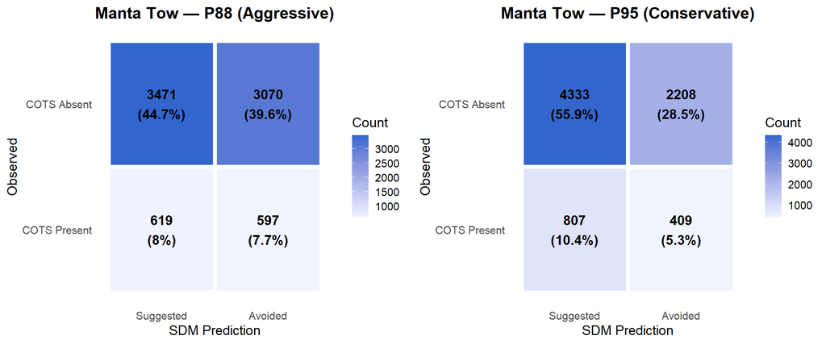

```r
# Function to build and plot a confusion matrix
plot_confusion_matrix <- function(predicted_suggested, observed_presence, title) {
  cm_df <- data.frame(
    Predicted = factor(ifelse(predicted_suggested, "Suggested", "Avoided"), levels = c("Suggested", "Avoided")),
    Observed  = factor(ifelse(observed_presence, "COTS Present", "COTS Absent"), levels = c("COTS Present", "COTS Absent"))
  )
  cm_counts <- cm_df %>%
    count(Predicted, Observed) %>%
    group_by() %>%
    mutate(pct = n / sum(n) * 100)

  ggplot(cm_counts, aes(x = Predicted, y = Observed, fill = n)) +
    geom_tile(color = "white", linewidth = 2) +
    geom_text(aes(label = paste0(n, "\n(", round(pct, 1), "%)") ), size = 5, fontface = "bold") +
    scale_fill_gradient(low = "#f0f4ff", high = "#3366cc") +
    theme_minimal(base_size = 14) +
    labs(title = title, x = "SDM Prediction", y = "Observed", fill = "Count") +
    theme(
      plot.title = element_text(face = "bold", hjust = 0.5),
      panel.grid = element_blank()
    )
}

# Manta Tow Confusion Matrices
p1 <- plot_confusion_matrix(
  manta_eval_2025$sug_Tow_P88, manta_eval_2025$presence_any,
  "Manta Tow — P88 (Aggressive)"
)
p2 <- plot_confusion_matrix(
  manta_eval_2025$sug_Tow_P95, manta_eval_2025$presence_any,
  "Manta Tow — P95 (Conservative)"
)

gridExtra::grid.arrange(p1, p2, ncol = 2)
```

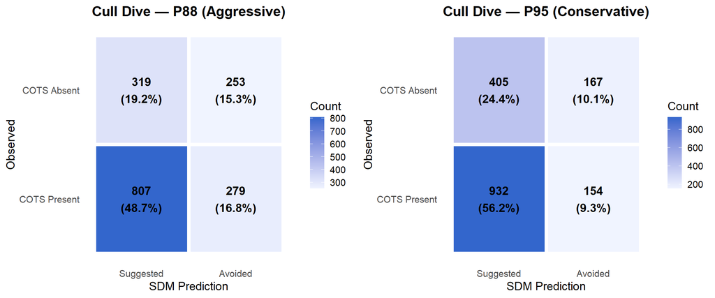

```r
# Cull Dive Confusion Matrices (is_non_problematic as "COTS Absent" proxy)
p3 <- plot_confusion_matrix(
  !cull_eval_2025$avoid_Tow_P88, !cull_eval_2025$is_non_problematic,
  "Cull Dive — P88 (Aggressive)"
)
p4 <- plot_confusion_matrix(
  !cull_eval_2025$avoid_Tow_P95, !cull_eval_2025$is_non_problematic,
  "Cull Dive — P95 (Conservative)"
)

gridExtra::grid.arrange(p3, p4, ncol = 2)
```

## 5. Step D: Visual Mapping

Below are maps for each reef showing the underlying 2025 SDM probability. The operational units displayed are the **100m Buffered Tow Regions**, categorized by the **95th Percentile (P95) Threshold** (Red = Suggested, Grey = Avoided). Individual manta tows and cull dive locations are also plotted to show what falls inside the suggested operational areas.

```r
plot_reef_map <- function(r, tow_sf, dive_sf, region_sf, reef_name, p_min, p_max) {
  # Bounding box around features
  bb_t <- if(nrow(tow_sf) > 0) st_bbox(tow_sf) else NULL
  bb_d <- if(nrow(dive_sf) > 0) st_bbox(dive_sf) else NULL

  xmin <- min(c(bb_t["xmin"], bb_d["xmin"]), na.rm=TRUE)
  ymin <- min(c(bb_t["ymin"], bb_d["ymin"]), na.rm=TRUE)
  xmax <- max(c(bb_t["xmax"], bb_d["xmax"]), na.rm=TRUE)
  ymax <- max(c(bb_t["ymax"], bb_d["ymax"]), na.rm=TRUE)

  pad <- 2000 # 2km padding
  ext_map <- terra::ext(xmin - pad, xmax + pad, ymin - pad, ymax + pad)

  rc <- terra::crop(r, ext_map)

  # Scale aggregate factor to keep cell count manageable (~10,000 pixels) for fast plotting
  fact <- ceiling(sqrt(terra::ncell(rc) / 10000))
  if(fact > 1) {
    rc <- terra::aggregate(rc, fact = fact, fun = "mean", na.rm = TRUE)
  }

  rdf <- as.data.frame(rc, xy = TRUE, na.rm = TRUE)
  names(rdf)[3] <- "prob"

  # Determine if region is suggested based on P95 threshold
  region_sf <- region_sf %>%
    mutate(is_suggested = !is.na(reg_p95) & reg_p95 >= thresh_2025_p95)

  gg <- ggplot() +
    geom_raster(data = rdf, aes(x = x, y = y, fill = prob)) +
    # Plot Operational Zones
    geom_sf(data = region_sf, aes(color = is_suggested), fill = NA, linewidth = 1.2, linetype = "dashed") +
    scale_color_manual(values = c("TRUE" = "red", "FALSE" = "grey70")) +
    # Plot Tows and Dives
    geom_sf(data = tow_sf, color = "black", linewidth = 0.5) +
    geom_sf(data = dive_sf, shape = 21, fill = "white", color = "black", size = 2) +
    scale_fill_viridis_c(
      option = "C",
      na.value = NA,
      limits = c(p_min, p_max),
      oob = scales::squish
    ) +
    theme_minimal() +
    labs(
      title = paste("Operational Zonal Map:", reef_name),
      subtitle = paste0("Red Dashed = Suggested 100m Zone (P95), Grey Dashed = Avoided Zone\nScale clipped to ", p_min, "-", p_max),
      fill  = "2025 SDM Prob",
      color = "Suggested Zone"
    )
  return(gg)
}

# Generate plots for each reef
cull_sf_2025 <- cull_sf %>% filter(as.Date(SurveyDate) >= as.Date("2025-01-01"))

for(r_name in reef_select) {
  t_sf <- manta_eval_2025 %>% filter(ReefName == r_name)
  d_sf <- cull_sf_2025 %>% filter(ReefName == r_name)
  r_sf <- tow_regions %>% filter(ReefName == r_name)

  if(nrow(t_sf) > 0 || nrow(d_sf) > 0) {
    message(paste("Processing map for:", r_name))
    cat("\n### ", r_name, "\n")
    p <- plot_reef_map(prob_year2025, t_sf, d_sf, r_sf, r_name, p_min_2025, p_max_2025)
    print(p)
    cat("\n")
  }
}
```

### Tongue Reef (16-026)

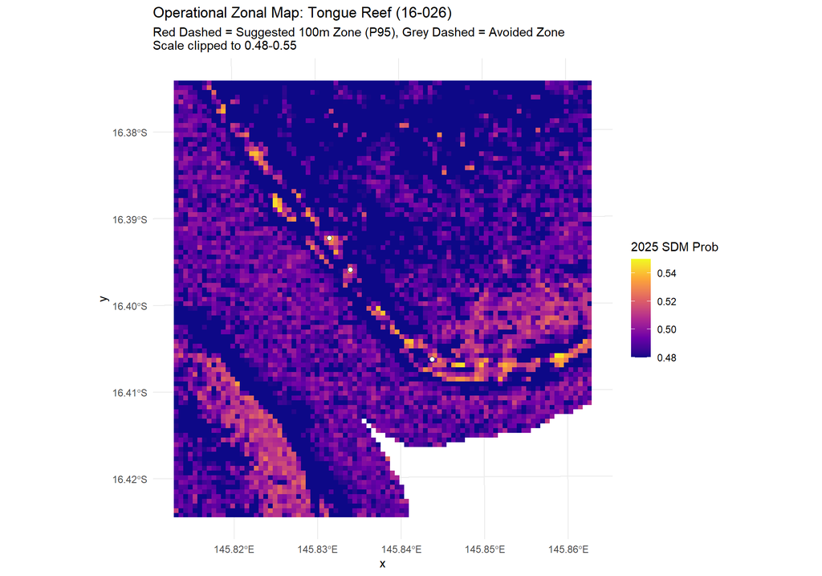

### Batt Reef (16-029)

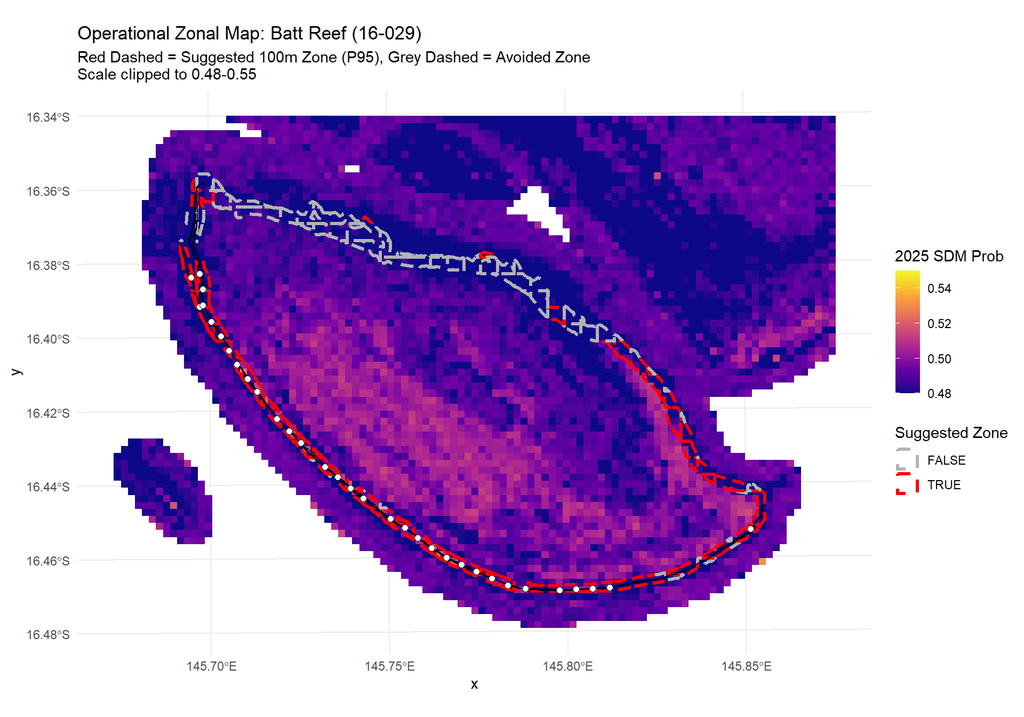

### (Big) Broadhurst Reef (No 1) (18-100a)

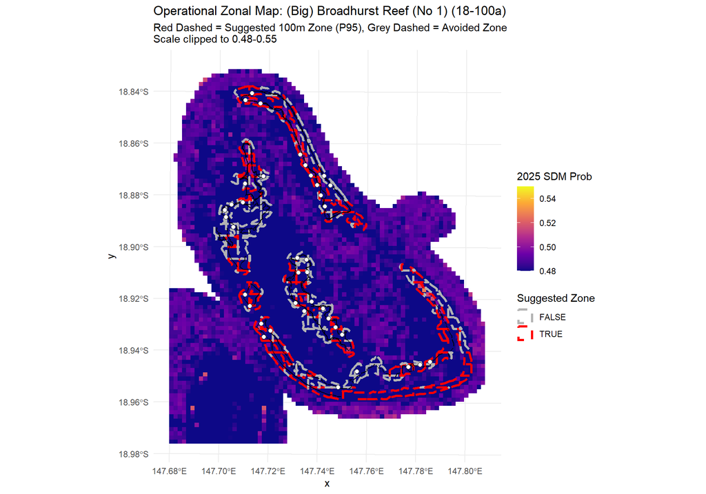

### Britomart Reef (18-024)

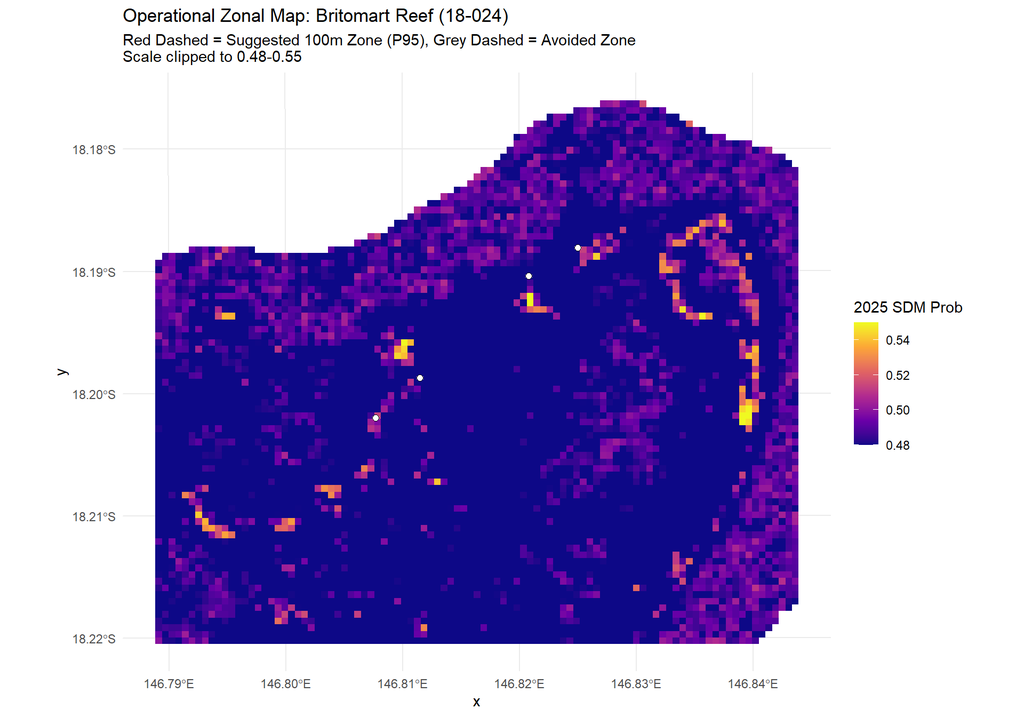

### Davies Reef (18-096)

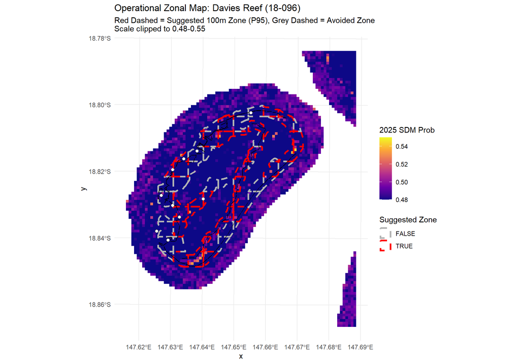

### Heron Reef (23-052a)

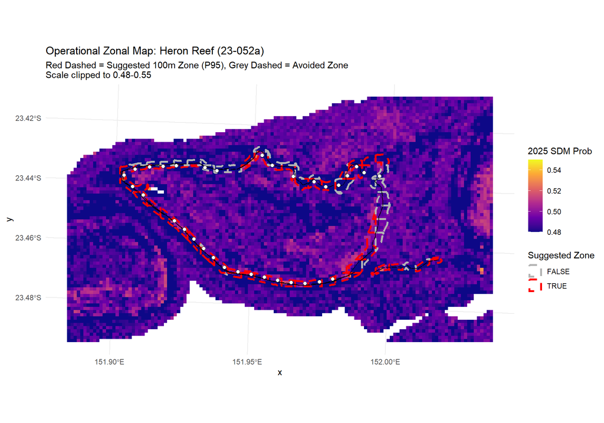